# Lab 5

Amanda Murphy

10/18/2021

### Review rnorm / histograms / sampling

```r
rnorm(n=10,mean=0,sd=1)
```

```
##  [1] -0.95313802  0.06651229 -0.59581716 -0.01866072 -0.59655937  1.63798546
##  [7] -1.08729042  1.11927459  0.18430236 -0.31333454
```

```r
library(ggplot2)
```

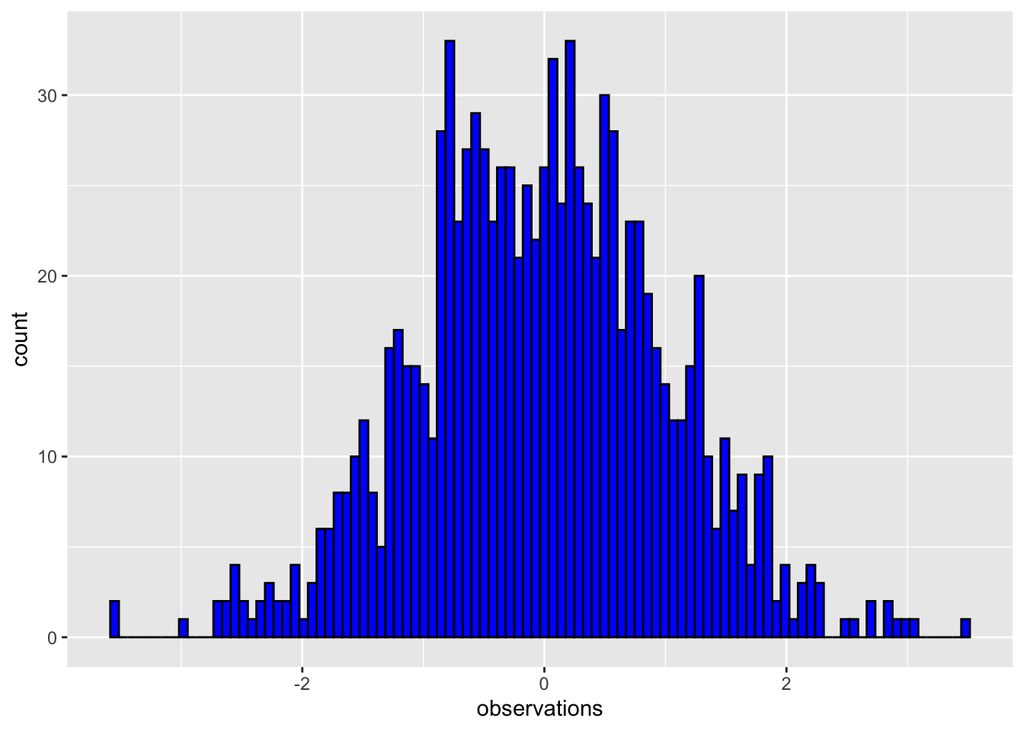

```r
some_data <- data.frame(observations = rnorm(1000,mean=0,sd=1),
                        type ="A")

ggplot(some_data, aes(x=observations)) +
  geom_histogram(bins = 100, color= "black",
                 fill = "blue")
```

```r
rnorm(1,0,1)
```

```
## [1] 0.7031483
```

```r
some_data$observations[some_data$observations > 2.5]
```

```
## [1] 2.910661 3.461517 2.671966 3.031148 2.548856 2.806216 2.870555 2.998121
## [9] 2.724504
```

```r
length(some_data$observations[some_data$observations > 2.5])
```

```
## [1] 9
```

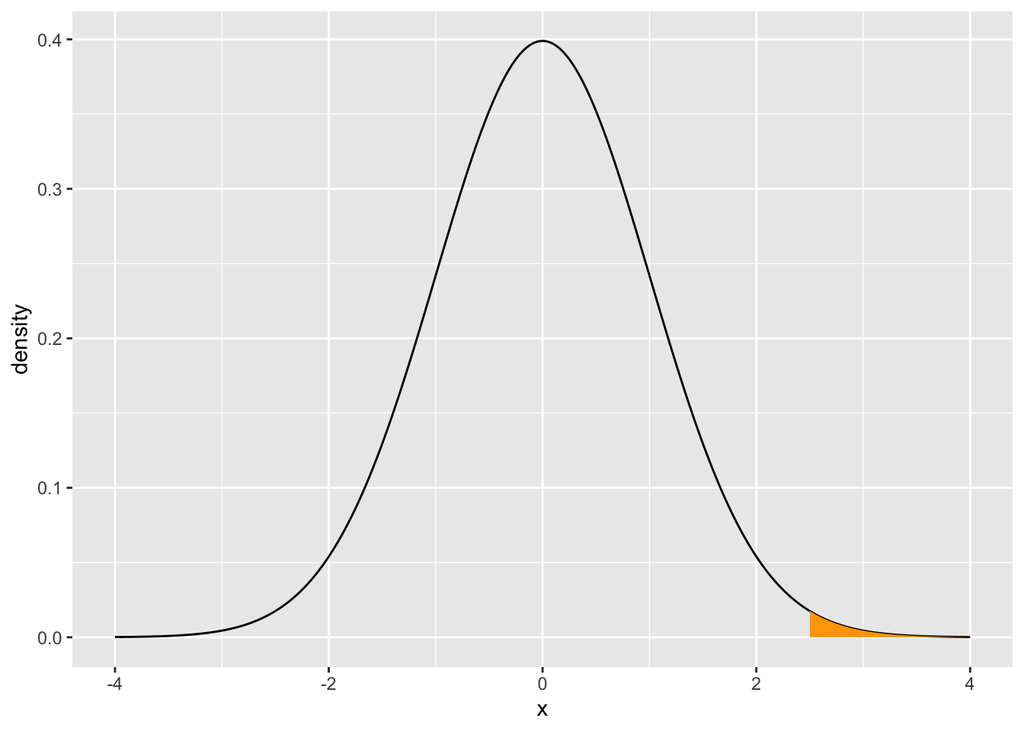

```r
library(ggplot2)
library(dplyr)
some_data <- data.frame(density = dnorm(seq(-4,4,.001), mean=0, sd=1),
                         x= seq(-4,4,.001))

region_data <- some_data %>%
filter(x > 2.5)


ggplot(some_data, aes(x=x, y=density)) +
  geom_line() +
  geom_ribbon(data = region_data,
              fill = "orange",
              aes(ymin=0,ymax=density))
```

## pnorm

```r
pnorm(2.5, mean=0, sd=1)
```

```
## [1] 0.9937903
```

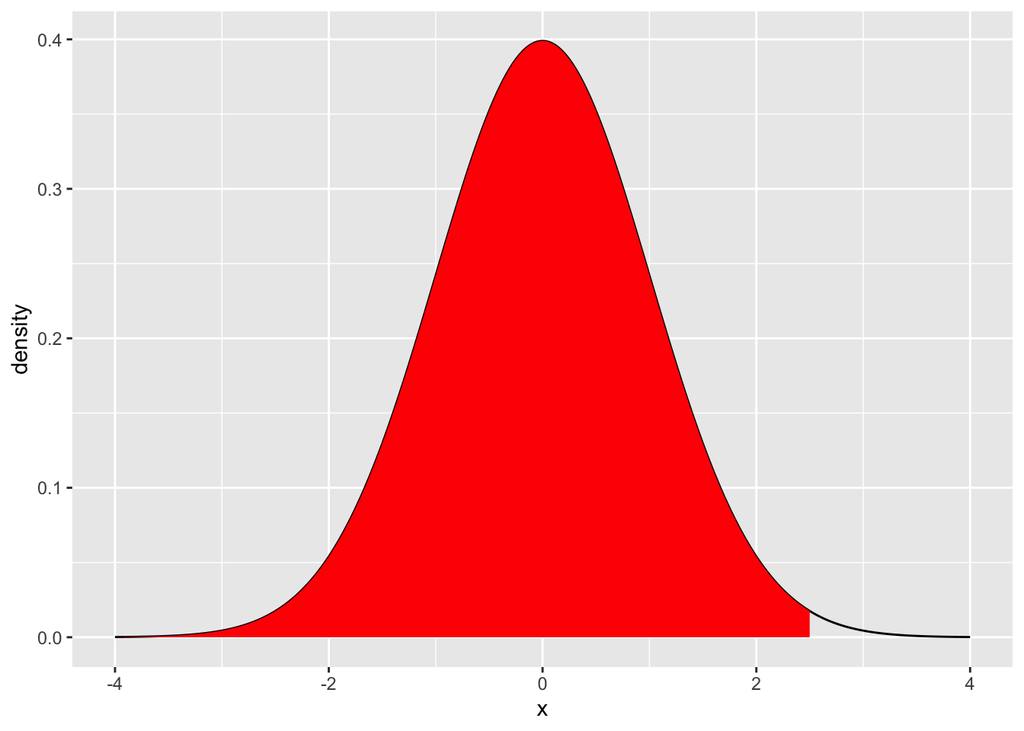

```r
some_data <- data.frame(density = dnorm(seq(-4,4,.001),mean= 0, sd=1),
                         x=seq(-4,4,.001))

region_data <- some_data %>%
  filter(x <2.5)

ggplot(some_data, aes(x=x, y=density)) +
  geom_line()+
  geom_ribbon(data = region_data,
              fill="red",
              aes(ymin=0,ymax=density))
```

```r
1- pnorm(2.5,mean=0,sd=1)
```

```
## [1] 0.006209665
```

```r
pnorm(2.5, mean=0, sd=1, lower.tail= FALSE)
```

```
## [1] 0.006209665
```

```r
qnorm(.5, mean=0, sd=1)
```

```
## [1] 0
```

```r
qnorm(.05, mean=0, sd=1, lower.tail = FALSE)
```

```
## [1] 1.644854
```

##Sampling Distribution

```r
mean(rnorm(10,mean=0,sd=1))
```

```
## [1] 0.00146029
```

Trust but verify. We trust that the rnorm() will generate random deviates in accordance with the definition of the normal distribution. For example, we learned in this lab, that a normal distribution with mean = 0, and sd =1 , should only produce values larger than 2.5 with a specific small probability, that is P(x>2.5) = 0.006209665. Verify this is approximately the case by randomly sampling 1 million numbers from this distribution, and calculate what proportion of numbers are larger than 2.5. (1 point)

```r
pnorm(2.5,0,1,lower.tail = FALSE)
```

```
## [1] 0.006209665
```

```r
my_sample <- rnorm(1000000,mean = 0, sd=1)

selection <- my_sample[my_sample > 2.5]
length(selection)/1000000
```

```
## [1] 0.006369
```

2. If performance on a standardized test was known to follow a normal distribution with mean 100 and standard deviation 10, and 10,000 people took the test, how many people would be expected to achieve a score higher than 3 standard deviations from the mean? (1 point)

```r
pnorm(q=130,mean=100,sd=10,lower.tail = FALSE)
```

```
## [1] 0.001349898
```

```r
10000*pnorm(q=130,mean=100,sd=10,lower.tail = FALSE)
```

```
## [1] 13.49898
```

3.You randomly sample 25 numbers from a normal distribution with mean = 10 and standard deviation = 20. You obtain a sample mean of 12. You want to know the probability that you could have received a sample mean of 12 or larger.

Create a sampling distribution of the mean for this scenario with at least 10,000 sample means (1 point). Then, calculate the proportion of sample means that are 12 or larger (1 point).

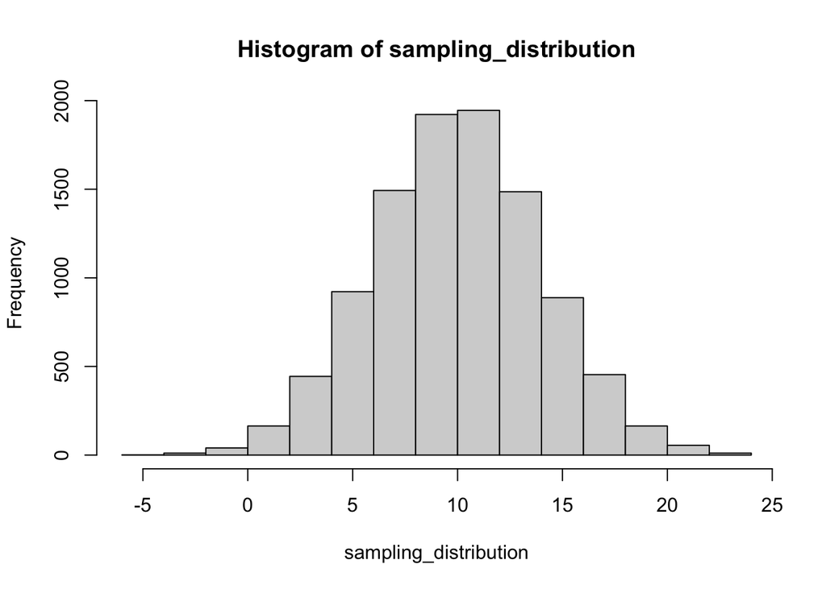

```r
sampling_distribution <- replicate(10000, mean(rnorm(25, mean = 10,sd = 20)))
hist(sampling_distribution)
```

```r
length(sampling_distribution[sampling_distribution > 12])/10000
```

```
## [1] 0.3058
```

4. You randomly sample 100 numbers from a normal distribution with mean = 10 and standard deviation = 20. You obtain a sample mean of 12. You want to know the probability that you could have received a sample mean of 12 or larger. Create a sampling distribution of the mean for this scenario with at least 10,000 sample means. Then, calculate the proportion of sample means that are 12 or larger. Is the proportion different from question 3, why? (1 point).

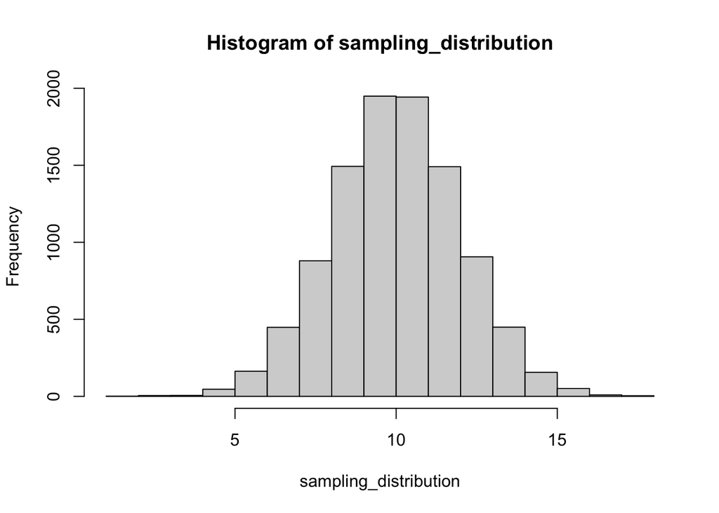

```r
sampling_distribution <- replicate(10000, mean(rnorm(100, mean = 10,sd = 20)))
hist(sampling_distribution)
```

```r
length(sampling_distribution[sampling_distribution >= 12])/10000
```

```
## [1] 0.1575
```

### In a smaller sample size of 25 will be more variance between means of a normal distribution with a mean of 10, allowing for a larger percentage of numbers to be further away from the mean of 10 and equalling larger than 12. In a larger sample, the variance between numbers will decrease, meaning they will be closer to the mean of 10, making it more unlikely to be above 12.

5. You randomly sample 25 numbers from a normal distribution with mean = 10 and standard deviation = 20. You obtain a sample standard deviation of 15. You want to know the probability that you could have received a sample standard deviation of 15 or less. Create a sampling distribution of standard deviations for this scenario with at least 10,000 sample standard deviations. Then, calculate the proportion of sample standard deviations that are 15 or less. (1 point)

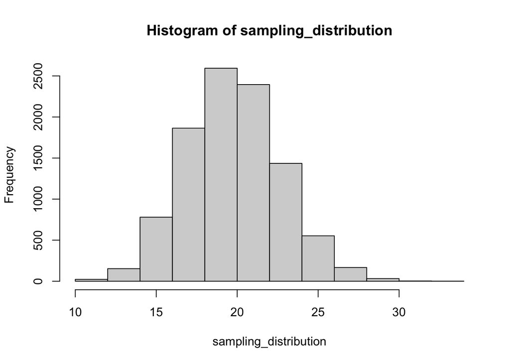

```r
sampling_distribution <- replicate(10000, sd(rnorm(25, mean = 10,sd = 20)))
hist(sampling_distribution)
```

```r
length(sampling_distribution[sampling_distribution <= 15])/10000
```

```
## [1] 0.048
```